### Install and load of necessary packages

```r
library(tidyverse)
library(lubridate)
```

### Importing data and joining together

Previous this step the csv files for every month were checked to respect the same structure and format using the CudaText editor + Linux terminal (tr -d command to strip ‘“’ characters in some files).

```r
jul22 <- read.csv("./data/202207-divvy-tripdata.csv")
aug22 <- read.csv("./data/202208-divvy-tripdata.csv")
sep22 <- read.csv("./data/202209-divvy-tripdata.csv")
oct22 <- read.csv("./data/202210-divvy-tripdata.csv")
nov22 <- read.csv("./data/202211-divvy-tripdata.csv")
dec22 <- read.csv("./data/202212-divvy-tripdata.csv")
jan23 <- read.csv("./data/202301-divvy-tripdata.csv")
feb23 <- read.csv("./data/202302-divvy-tripdata.csv")
mar23 <- read.csv("./data/202303-divvy-tripdata.csv")
apr23 <- read.csv("./data/202304-divvy-tripdata.csv")
may23 <- read.csv("./data/202305-divvy-tripdata.csv")
jun23 <- read.csv("./data/202306-divvy-tripdata.csv")
```

### Bindings all data into one

```r
total_rides <- rbind(jul22,aug22,sep22,oct22,nov22,dec22,jan23,feb23,mar23,apr23,may23,jun23)

# Checkout information
colnames(total_rides)
```

```
##  [1] "ride_id"            "rideable_type"      "started_at"
##  [4] "ended_at"           "start_station_name" "start_station_id"
##  [7] "end_station_name"   "end_station_id"     "start_lat"
## [10] "start_lng"          "end_lat"            "end_lng"
## [13] "member_casual"
```

```r
glimpse(total_rides)
```

```
## Rows: 5,779,444
## Columns: 13
## $ ride_id            <chr> "954144C2F67B1932", "292E027607D218B6", "5776585258…
## $ rideable_type      <chr> "classic_bike", "classic_bike", "classic_bike", "cl…
## $ started_at         <chr> "2022-07-05 08:12:47", "2022-07-26 12:53:38", "2022…
## $ ended_at           <chr> "2022-07-05 08:24:32", "2022-07-26 12:55:31", "2022…
## $ start_station_name <chr> "Ashland Ave & Blackhawk St", "Buckingham Fountain …
## $ start_station_id   <chr> "13224", "15541", "15541", "15541", "TA1307000117",…
## $ end_station_name   <chr> "Kingsbury St & Kinzie St", "Michigan Ave & 8th St"…
## $ end_station_id     <chr> "KA1503000043", "623", "623", "TA1307000164", "TA13…
## $ start_lat          <dbl> 41.90707, 41.86962, 41.86962, 41.86962, 41.89147, 4…
## $ start_lng          <dbl> -87.66725, -87.62398, -87.62398, -87.62398, -87.626…
## $ end_lat            <dbl> 41.88918, 41.87277, 41.87277, 41.79526, 41.93625, 4…
## $ end_lng            <dbl> -87.63851, -87.62398, -87.62398, -87.59647, -87.652…
## $ member_casual      <chr> "member", "casual", "casual", "casual", "member", "…
```

### Let’s make some cleaning

```r
# Remove some columns we won't be using
total_rides <- total_rides[,!names(total_rides) %in% c("start_lat", "start_lng","end_lat","end_lng")]

# Split timestamp into columns so we can determine trips_duration
total_rides$date <- as.Date(total_rides$started_at)
total_rides$month <- format(as.Date(total_rides$date),"%m")
total_rides$day <- format(as.Date(total_rides$date),"%d")
#total_rides$year <- format(as.Date(total_rides$year),"%Y")
total_rides$days_of_week <- format(as.Date(total_rides$date),"%A")

# Create new column to find trip duration
total_rides$trip_duration <- difftime(total_rides$ended_at, total_rides$started_at)
# Convert data type of trip_duration to numeric
total_rides$trip_duration <- as.numeric(as.character(total_rides$trip_duration))
is.numeric(total_rides$trip_duration)
```

```
## [1] TRUE
```

```r
# Validation
glimpse(total_rides)
```

```
## Rows: 5,779,444
## Columns: 14
## $ ride_id            <chr> "954144C2F67B1932", "292E027607D218B6", "5776585258…
## $ rideable_type      <chr> "classic_bike", "classic_bike", "classic_bike", "cl…
## $ started_at         <chr> "2022-07-05 08:12:47", "2022-07-26 12:53:38", "2022…
## $ ended_at           <chr> "2022-07-05 08:24:32", "2022-07-26 12:55:31", "2022…
## $ start_station_name <chr> "Ashland Ave & Blackhawk St", "Buckingham Fountain …
## $ start_station_id   <chr> "13224", "15541", "15541", "15541", "TA1307000117",…
## $ end_station_name   <chr> "Kingsbury St & Kinzie St", "Michigan Ave & 8th St"…
## $ end_station_id     <chr> "KA1503000043", "623", "623", "TA1307000164", "TA13…
## $ member_casual      <chr> "member", "casual", "casual", "casual", "member", "…
## $ date               <date> 2022-07-05, 2022-07-26, 2022-07-03, 2022-07-31, 20…
## $ month              <chr> "07", "07", "07", "07", "07", "07", "07", "07", "07…
## $ day                <chr> "05", "26", "03", "31", "13", "01", "18", "28", "10…
## $ days_of_week       <chr> "martes", "martes", "domingo", "domingo", "miércole…
## $ trip_duration      <dbl> 705, 113, 463, 3509, 1578, 523, 689, 1853, 333, 687…
```

```r
# Checkout how many row we have now
nrow(total_rides)
```

```
## [1] 5779444
```

```r
# [1] output 5,779,444

# So, we clean all records that have null/void information
# First, to count trip_duration with zero or negative value.
sum(total_rides$trip_duration <= 0)
```

```
## [1] 574
```

```r
# [1] output 574

# Delete bad data
total_rides_C1 <- total_rides[!(total_rides$trip_duration <= 0),]
sum(total_rides_C1$trip_duration <= 0)
```

```
## [1] 0
```

```r
# [1] output 0
nrow(total_rides_C1)
```

```
## [1] 5778870
```

```r
# [1] output 5,778,870

# Clean and delete all the records with void value un the start/end station
total_rides_C1 <- subset(total_rides_C1, start_station_name != "")
total_rides_C1 <- subset(total_rides_C1, end_station_name != "")
nrow(total_rides_C1)
```

```
## [1] 4409006
```

```r
# [1] output 4,409,006
```

### So we start making some analysis

```r
summary(total_rides_C1$trip_duration)
```

```
##      Min.   1st Qu.    Median      Mean   3rd Qu.      Max.
##       1.0     343.0     600.0     963.3    1071.0 1922127.0
```

```r
# [1] output
#     Min.   1st Qu.    Median      Mean   3rd Qu.      Max.
#      1.0     343.0     600.0     963.3    1071.0 1922127.0
#
avg_ride_duration <- aggregate(total_rides_C1$trip_duration ~ total_rides_C1$member_casual, FUN = mean)
median_value <- aggregate(total_rides_C1$trip_duration ~ total_rides_C1$member_casual, FUN = median)
max_ride_duration <- aggregate(total_rides_C1$trip_duration ~ total_rides_C1$member_casual, FUN = max)
min_ride_duration <- aggregate(total_rides_C1$trip_duration ~ total_rides_C1$member_casual, FUN = min)
print(avg_ride_duration)
```

```
##   total_rides_C1$member_casual total_rides_C1$trip_duration
## 1                       casual                    1350.0643
## 2                       member                     726.1395
```

```r
print(median_value)
```

```
##   total_rides_C1$member_casual total_rides_C1$trip_duration
## 1                       casual                          771
## 2                       member                          520
```

```r
print(max_ride_duration)
```

```
##   total_rides_C1$member_casual total_rides_C1$trip_duration
## 1                       casual                      1922127
## 2                       member                        89872
```

```r
print(min_ride_duration)
```

```
##   total_rides_C1$member_casual total_rides_C1$trip_duration
## 1                       casual                            1
## 2                       member                            1
```

```r
total_rides_C1$days_of_week <- ordered(total_rides_C1$days_of_week , levels = c("domingo","lunes","martes","miércoles","jueves","viernes","sábado"))
```

### Let us show some grfx with the insights.

**1. Comparison between types of users.**

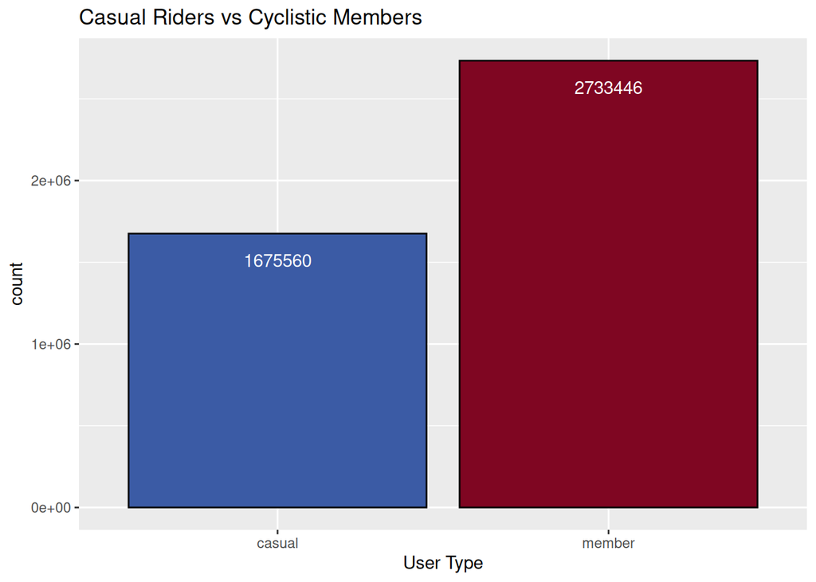

```r
total_rides_C1 %>%
    ggplot(mapping = aes(x=member_casual))+geom_bar(color="black",fill=c("#3B5BA5", "#7F0622"))+geom_text(aes(label=after_stat(count)),stat = "count",vjust=2.5,color="white")+ labs(title = "Casual Riders vs Cyclistic Members",x="User Type")
```

Total rides: 4,409,006

Avg Ride Duration (seconds/minutes) casual 1,350.1 / 22.5 member 726.1 / 12.1

Max Ride Duration (seconds/minutes) casual 1,922,127.0 / 32,035.5 member 89,872.0 / 1,497.9

Participation by Usertype Casual 1,675,560 38% Member 2,733,446 62% **Total 4,409,006 100%**

**2. Cyclist members preferred bikes**

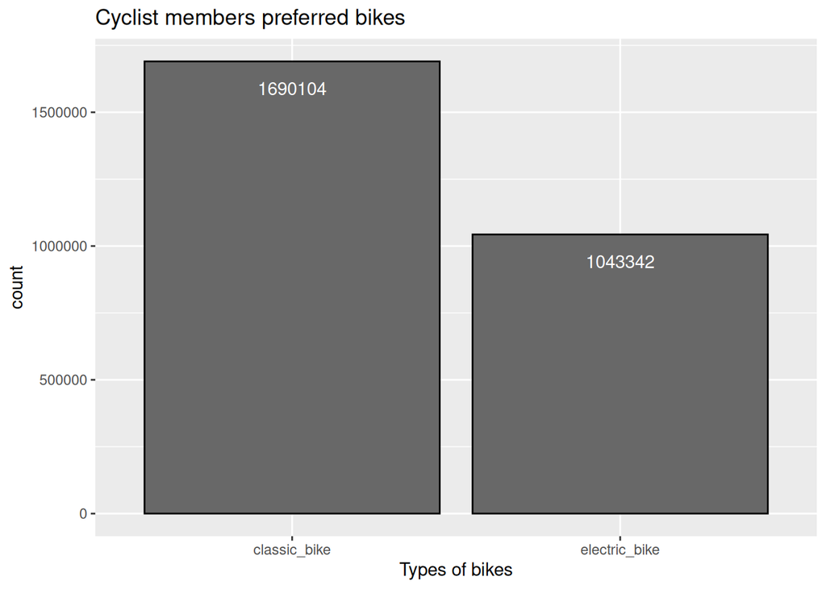

```r
total_rides_C1 %>%
  filter(total_rides_C1$member_casual == "member") %>%
    ggplot(mapping = aes(x=rideable_type))+geom_bar(color="black",fill=c("#686868"))+geom_text(aes(label=after_stat(count)),stat = "count",vjust=2.5,color="white")+ labs(title = "Cyclist members preferred bikes",x="Types of bikes")
```

Rideable Type Classic bike 1,690,104 62% Electric bike 1,043,342 38%

Total Members rides 2,733,446 100%

**3. Casual riders preferred bikes analysis**

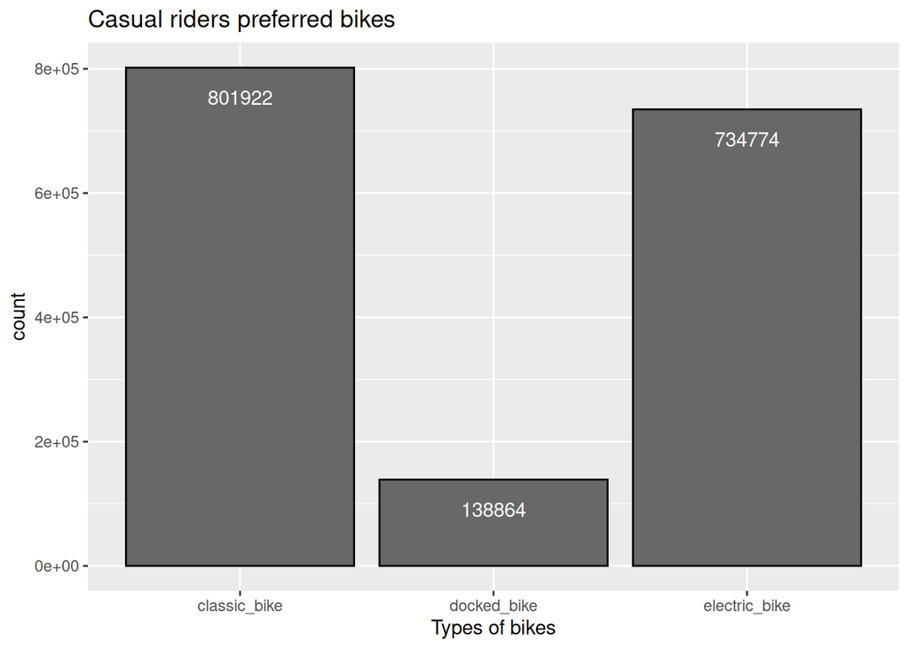

```r
total_rides_C1 %>%
  filter(total_rides_C1$member_casual == "casual") %>%
    ggplot(mapping = aes(x=rideable_type))+geom_bar(color="black",fill=c("#686868"))+geom_text(aes(label=after_stat(count)),stat = "count",vjust=2.5,color="white")+ labs(title = "Casual riders preferred bikes",x="Types of bikes")
```

Classic bikes is most favorite among the users and the second favorite bike is electric bikes. NOTE : Few Casual riders still uses Docked bikes whereas Cyclist members Completely Stopped using Docked bikes

**4. No.of rides of cyclist members on each month**

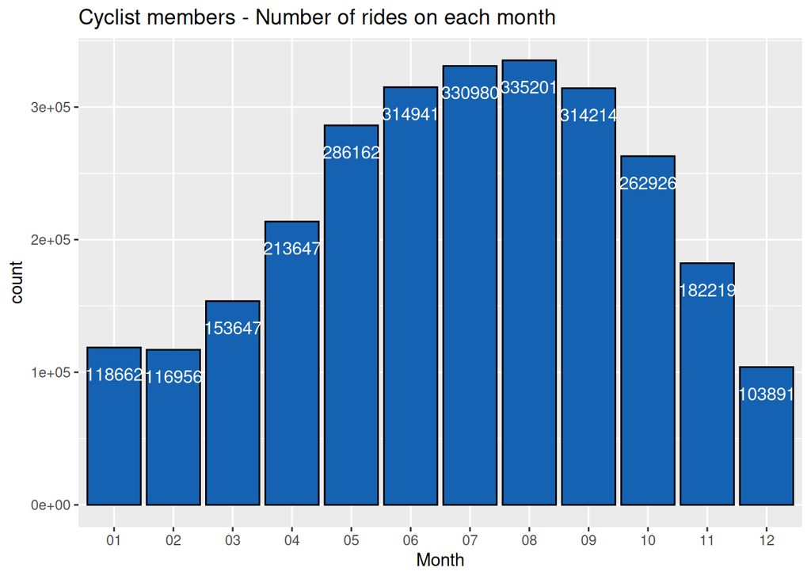

```r
total_rides_C1 %>% filter(total_rides_C1$member_casual == "member") %>%
    ggplot(mapping = aes(x=month))+geom_bar(color="black",fill=c("#1662B2"))+geom_text(aes(label=after_stat(count)),stat = "count",vjust=2.5,color="white")+ labs(title = "Cyclist members - Number of rides on each month",x="Month")
```

For Cyclist members the maximum rides occurs in the month June, July, August and September.

**5. No.of rides of Casual riders on each month**

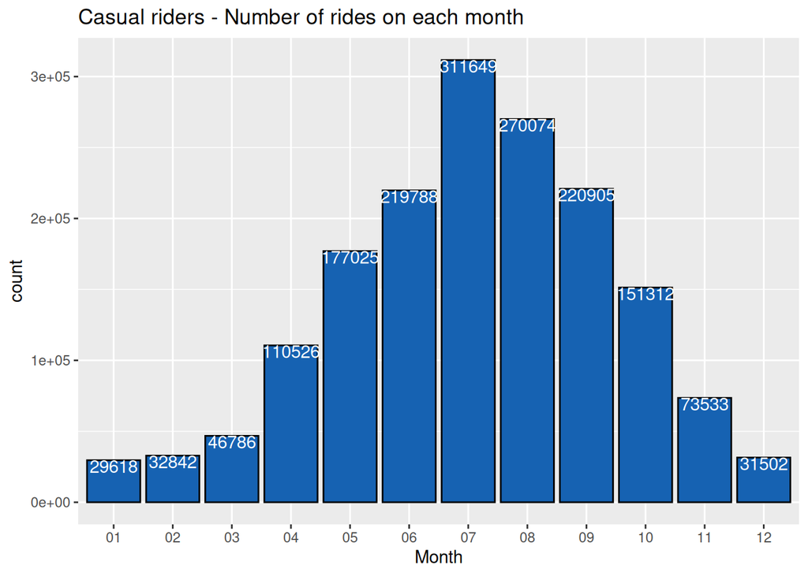

```r
total_rides_C1 %>%
  filter(total_rides_C1$member_casual == "casual") %>%
    ggplot(mapping = aes(x=month))+geom_bar(color="black",fill=c("#1662b2"))+geom_text(aes(label=after_stat(count)),stat = "count",vjust=.95,color="white")+ labs(title = "Casual riders - Number of rides on each month",x="Month")
```

For Casual riders the maximum rides occurs in the month July

**6. Avg ride time for each day**

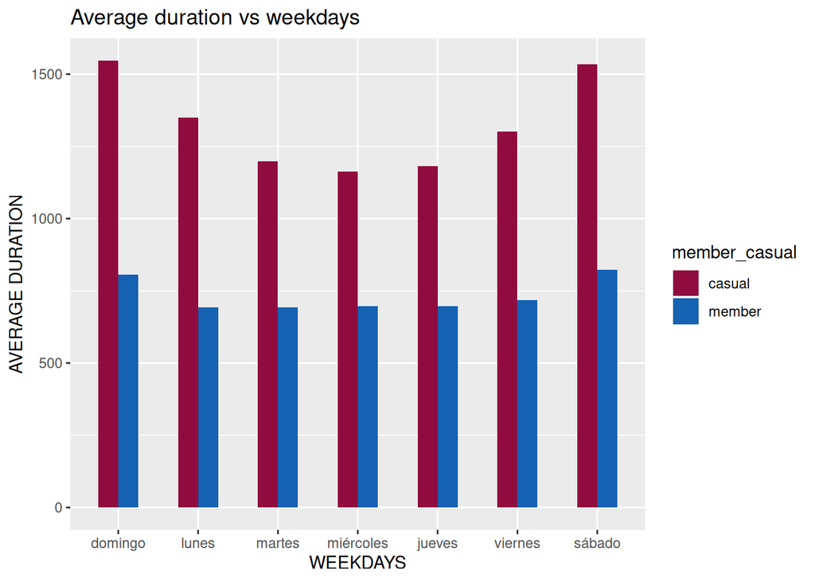

```r
total_rides_C1 %>%
  group_by(member_casual,days_of_week) %>%
  summarise(avg_duration = mean(trip_duration)) %>%
  arrange(member_casual,days_of_week) %>%
  ggplot(mapping = aes(x= days_of_week, y=avg_duration, fill= member_casual))+
  geom_col(position="dodge",width = 0.5)+scale_fill_manual(values=c("#900c3f", "#1662b2"))+
  labs(title = "Average duration vs weekdays",x="WEEKDAYS",y="AVERAGE DURATION")
```

Casual riders averages more than Cyclist members and for Cyclist members the average trip duration is consistent throughout the week

**7. No.of rides by both users**

```r
total_rides_C1 %>%
  group_by(member_casual,days_of_week) %>%
  summarise(no_of_rides = n()) %>%
  arrange(member_casual,days_of_week)
```

| member_casual | days_of_week | no_of_rides |
| --- | --- | --- |
| casual | domingo | 267186 |
| casual | lunes | 189314 |
| casual | martes | 190147 |
| casual | miércoles | 204942 |
| casual | jueves | 219859 |
| casual | viernes | 254712 |
| casual | sábado | 349400 |
| member | domingo | 295403 |
| member | lunes | 376552 |
| member | martes | 432671 |

[output cut: 4 more lines]

**8. No of rides by day**

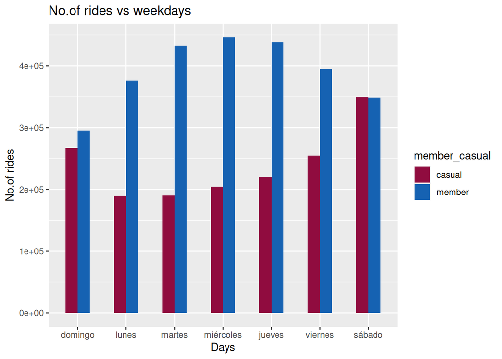

```r
total_rides_C1 %>%
  group_by(member_casual,days_of_week) %>%
  summarise(no_of_rides = n()) %>%
  arrange(member_casual,days_of_week) %>%
  ggplot(mapping = aes(x= days_of_week, y=no_of_rides, fill= member_casual))+
  geom_col(position="dodge",width = 0.5)+scale_fill_manual(values=c("#900c3f", "#1662b2"))+
  labs(title = "No.of rides vs weekdays",x="Days",y="No.of rides")
```

**9. Most used station**

```r
total_rides_C1 %>%
  filter(member_casual=="member") %>%
  group_by(start_station_name) %>%
  drop_na() %>%
  summarise(n=n()) %>%
  arrange(desc(n)) %>%
  slice_max(n,n=5)
```

| start_station_name | n |
| --- | --- |
| Kingsbury St & Kinzie St | 23489 |
| Clark St & Elm St | 21681 |
| Clinton St & Washington Blvd | 21035 |
| Wells St & Concord Ln | 19748 |
| Loomis St & Lexington St | 19588 |

#Graph

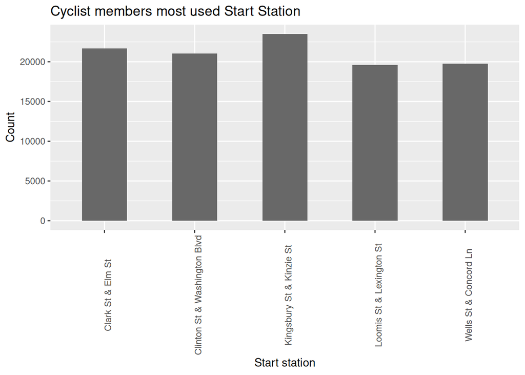

```r
total_rides_C1 %>%
  filter(member_casual=="member") %>%
  group_by(start_station_name) %>%
  drop_na() %>%
  summarise(n=n()) %>%
  arrange(desc(n)) %>%
  slice_max(n,n=5) %>%
  ggplot(mapping = aes(x=start_station_name, y = n))+geom_col(fill = "#686868",width = 0.5)+ labs(title = "Cyclist members most used Start Station",x="Start station",y="Count") + theme(axis.text.x = element_text(angle = 90))
```

**10. Most used station with Casual users**

```r
total_rides_C1 %>%
  filter(member_casual=="casual") %>%
  group_by(start_station_name) %>%
  drop_na() %>%
  summarise(n=n()) %>%
  arrange(desc(n)) %>%
  slice_max(n,n=5)
```

| start_station_name | n |
| --- | --- |
| Streeter Dr & Grand Ave | 49770 |
| DuSable Lake Shore Dr & Monroe St | 29076 |
| Michigan Ave & Oak St | 22384 |
| Millennium Park | 21948 |
| DuSable Lake Shore Dr & North Blvd | 20317 |

#Graph

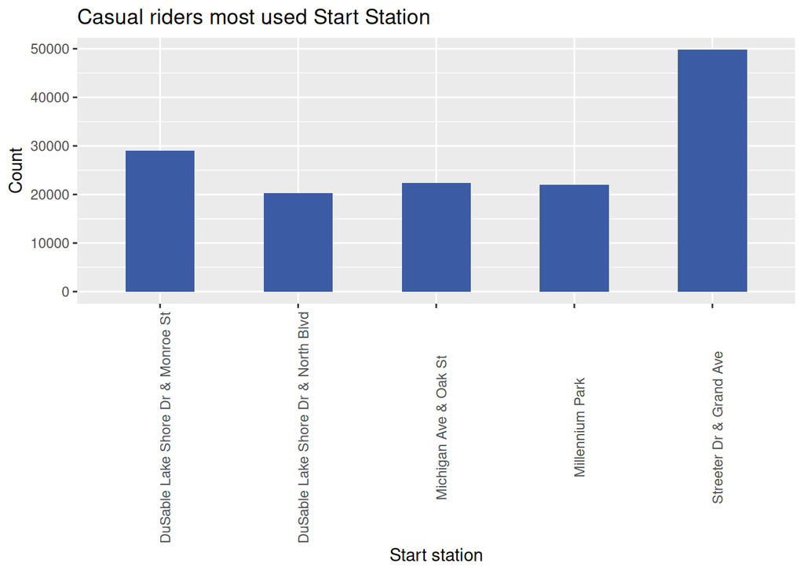

```r
total_rides_C1 %>%
  filter(member_casual=="casual") %>%
  group_by(start_station_name) %>%
  drop_na() %>%
  summarise(n=n()) %>%
  arrange(desc(n)) %>%
  slice_max(n,n=5) %>%
  ggplot(mapping = aes(x=start_station_name, y = n))+geom_col(fill = "#3B5BA5",width = 0.5)+ labs(title = "Casual riders most used Start Station",x="Start station",y="Count") + theme(axis.text.x = element_text(angle = 90))
```

**11. Most visited end station by Members users**

```r
total_rides_C1 %>%
  filter(member_casual=="member") %>%
  group_by(end_station_name) %>%
  drop_na() %>%
  summarise(n=n()) %>%
  arrange(desc(n)) %>%
  slice_max(n,n=5)
```

| end_station_name | n |
| --- | --- |
| Kingsbury St & Kinzie St | 23465 |
| Clinton St & Washington Blvd | 22003 |
| Clark St & Elm St | 21827 |
| Wells St & Concord Ln | 20646 |
| Loomis St & Lexington St | 19946 |

#Graph

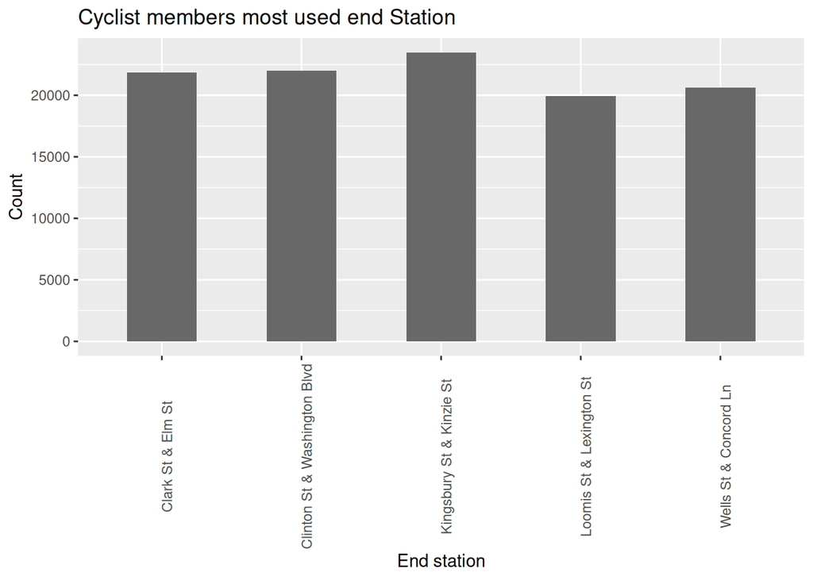

```r
total_rides_C1 %>%
  filter(member_casual=="member") %>%
  group_by(end_station_name) %>%
  drop_na() %>%
  summarise(n=n()) %>%
  arrange(desc(n)) %>%
  slice_max(n,n=5) %>%
  ggplot(mapping = aes(x=end_station_name, y = n))+geom_col(fill = "#686868",width = 0.5)+ labs(title = "Cyclist members most used end Station",x="End station",y="Count") + theme(axis.text.x = element_text(angle = 90))
```

**12. Casual riders most used end station**

```r
total_rides_C1 %>%
  filter(member_casual=="casual") %>%
  group_by(end_station_name) %>%
  drop_na() %>%
  summarise(n=n()) %>%
  arrange(desc(n)) %>%
  slice_max(n,n=5)
```

| end_station_name | n |
| --- | --- |
| Streeter Dr & Grand Ave | 53245 |
| DuSable Lake Shore Dr & Monroe St | 27000 |
| Millennium Park | 23969 |
| Michigan Ave & Oak St | 23897 |
| DuSable Lake Shore Dr & North Blvd | 23167 |

#Graph

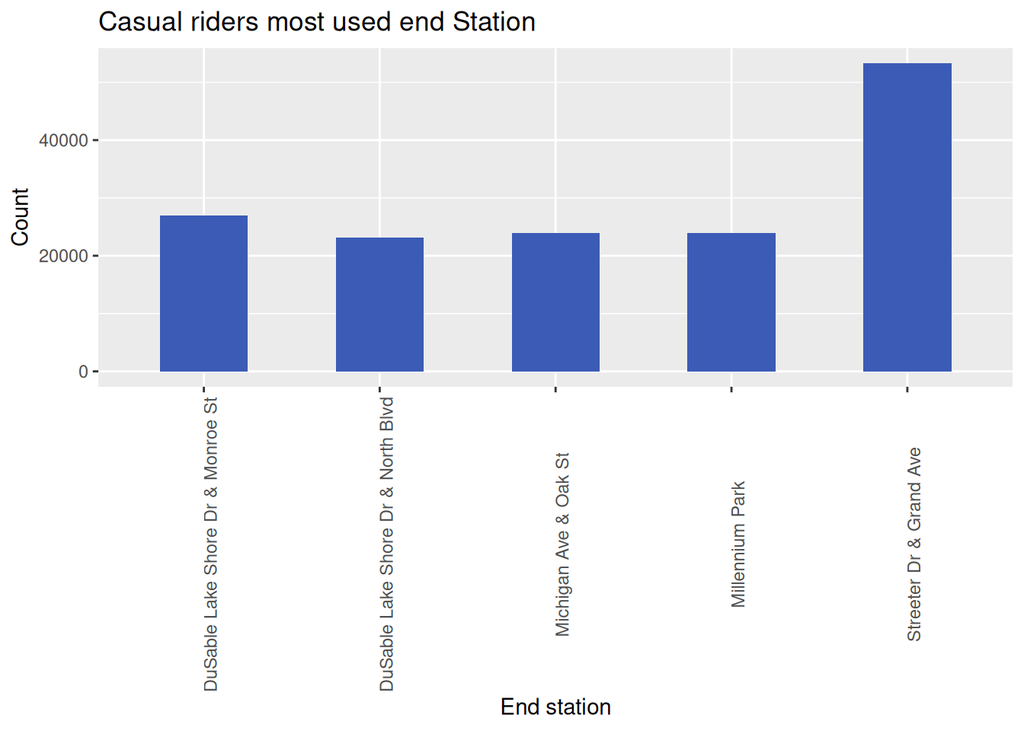

```r
total_rides_C1 %>%
  filter(member_casual=="casual") %>%
  group_by(end_station_name) %>%
  drop_na() %>%
  summarise(n=n()) %>%
  arrange(desc(n)) %>%
  slice_max(n,n=5) %>%
  ggplot(mapping = aes(x=end_station_name, y = n))+geom_col(fill = "#3B5Bb6",width = 0.5)+ labs(title = "Casual riders most used end Station",x="End station",y="Count") + theme(axis.text.x = element_text(angle = 90))
```

### Observations

**1. Most used bike** *Classic bike* is the most favorite bike for both the users and the second favorite bike is *electric bike*. Only few casual riders prefers docked bike whereas Cyclist members completely stopped using Docked bike

**2. Months** Highest number of rides happened during June, July, August and Septembre for both the users, the cyclist members rent more bikes than casual riders however the casual riders are more active during summer (June, July, August and September).

**4. Average Trip duration** Average trip duration for casual riders is more when compared to cyclist members.